# HW7_Sonam

Sonam Rathod

2024-11-21

# ARIMA

#### 1. Explain the output

```r
library(dplyr)
library(forecast)
```

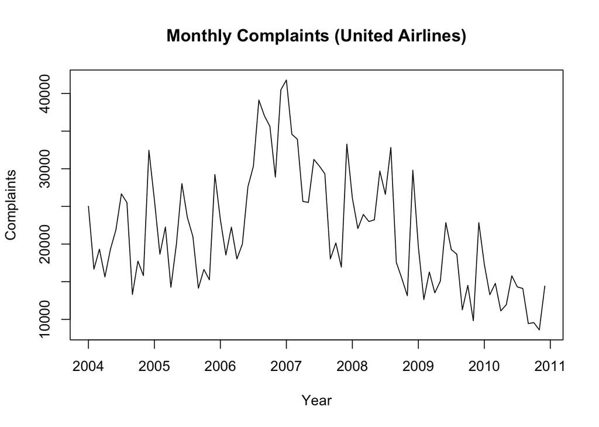

```r
baggagecomplaints <- read.csv("~/Downloads/baggagecomplaints.csv")

baggageUnited <- baggagecomplaints %>%
  filter(Airline == "United")

united_ts <- ts(baggageUnited$Baggage, start = c(2004, 1), end = c(2010,12), frequency = 12)
plot(united_ts, main = "Monthly Complaints (United Airlines)", xlab = "Year", ylab = "Complaints")
```

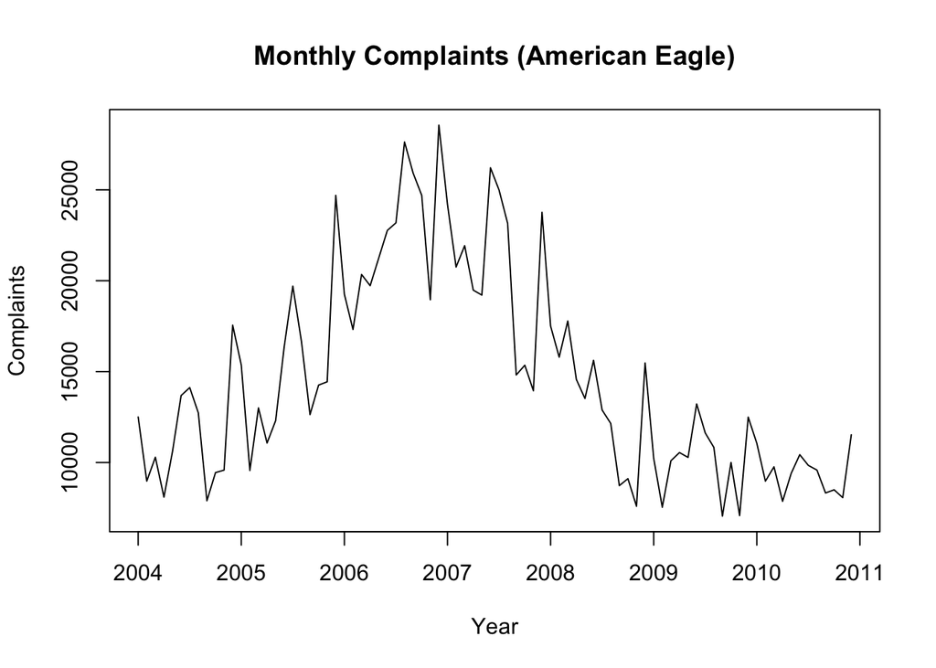

```r
baggageAmerican <- baggagecomplaints %>%
  filter(Airline == "American Eagle")

american_ts <- ts(baggageAmerican$Baggage, start = c(2004, 1), end = c(2010,12), frequency = 12)
plot(american_ts, main = "Monthly Complaints (American Eagle)", xlab = "Year", ylab = "Complaints")
```

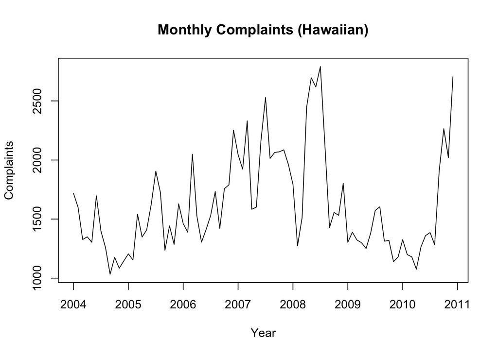

```r
baggageHawaiian <- baggagecomplaints %>%
  filter(Airline == "Hawaiian")

hawaiian_ts <- ts(baggageHawaiian$Baggage, start = c(2004, 1), end = c(2010,12), frequency = 12)
plot(hawaiian_ts, main = "Monthly Complaints (Hawaiian)", xlab = "Year", ylab = "Complaints")
```

```r
# United Airlines ARIMA

united_model <- auto.arima(united_ts, trace = TRUE, stepwise = FALSE)
```

```
##
##  ARIMA(0,1,0)(0,1,0)[12]                    : 1394.811
##  ARIMA(0,1,0)(0,1,1)[12]                    : Inf
##  ARIMA(0,1,0)(0,1,2)[12]                    : Inf
##  ARIMA(0,1,0)(1,1,0)[12]                    : 1382.555
##  ARIMA(0,1,0)(1,1,1)[12]                    : Inf
##  ARIMA(0,1,0)(1,1,2)[12]                    : Inf
##  ARIMA(0,1,0)(2,1,0)[12]                    : 1376.902
##  ARIMA(0,1,0)(2,1,1)[12]                    : Inf
##  ARIMA(0,1,0)(2,1,2)[12]                    : Inf
##  ARIMA(0,1,1)(0,1,0)[12]                    : 1396.608
##  ARIMA(0,1,1)(0,1,1)[12]                    : Inf
##  ARIMA(0,1,1)(0,1,2)[12]                    : Inf
##  ARIMA(0,1,1)(1,1,0)[12]                    : 1384.728
##  ARIMA(0,1,1)(1,1,1)[12]                    : Inf
##  ARIMA(0,1,1)(1,1,2)[12]                    : Inf
##  ARIMA(0,1,1)(2,1,0)[12]                    : 1379.078
##  ARIMA(0,1,1)(2,1,1)[12]                    : Inf
##  ARIMA(0,1,1)(2,1,2)[12]                    : Inf
##  ARIMA(0,1,2)(0,1,0)[12]                    : 1396.728
##  ARIMA(0,1,2)(0,1,1)[12]                    : Inf
##  ARIMA(0,1,2)(0,1,2)[12]                    : Inf
##  ARIMA(0,1,2)(1,1,0)[12]                    : 1384.998
##  ARIMA(0,1,2)(1,1,1)[12]                    : Inf
##  ARIMA(0,1,2)(1,1,2)[12]                    : Inf
##  ARIMA(0,1,2)(2,1,0)[12]                    : 1379.645
##  ARIMA(0,1,2)(2,1,1)[12]                    : Inf
##  ARIMA(0,1,3)(0,1,0)[12]                    : 1397.446
##  ARIMA(0,1,3)(0,1,1)[12]                    : Inf
##  ARIMA(0,1,3)(0,1,2)[12]                    : Inf
##  ARIMA(0,1,3)(1,1,0)[12]                    : 1384.859
##  ARIMA(0,1,3)(1,1,1)[12]                    : Inf
##  ARIMA(0,1,3)(2,1,0)[12]                    : 1378.422
##  ARIMA(0,1,4)(0,1,0)[12]                    : 1394.216
##  ARIMA(0,1,4)(0,1,1)[12]                    : Inf
##  ARIMA(0,1,4)(1,1,0)[12]                    : 1382.753
##  ARIMA(0,1,5)(0,1,0)[12]                    : 1395.944
##  ARIMA(1,1,0)(0,1,0)[12]                    : 1396.743
##  ARIMA(1,1,0)(0,1,1)[12]                    : Inf
##  ARIMA(1,1,0)(0,1,2)[12]                    : Inf
```

[output cut: 46 more lines]

```
##  ARIMA(3,1,0)(1,1,1)[12]                    : Inf
##  ARIMA(3,1,0)(2,1,0)[12]                    : 1377.17
##  ARIMA(3,1,1)(0,1,0)[12]                    : 1396.945
##  ARIMA(3,1,1)(0,1,1)[12]                    : Inf
##  ARIMA(3,1,1)(1,1,0)[12]                    : 1383.05
##  ARIMA(3,1,2)(0,1,0)[12]                    : Inf
##  ARIMA(4,1,0)(0,1,0)[12]                    : 1395.549
##  ARIMA(4,1,0)(0,1,1)[12]                    : Inf
##  ARIMA(4,1,0)(1,1,0)[12]                    : 1383.428
##  ARIMA(4,1,1)(0,1,0)[12]                    : 1397.625
##  ARIMA(5,1,0)(0,1,0)[12]                    : 1397.766
##
##
##
##  Best model: ARIMA(0,1,0)(2,1,0)[12]
```

```r
summary(united_model)
```

```
## Series: united_ts
## ARIMA(0,1,0)(2,1,0)[12]
##
## Coefficients:
##          sar1     sar2
##       -0.6600  -0.4056
## s.e.   0.1233   0.1295
##
## sigma^2 = 13141677:  log likelihood = -685.27
## AIC=1376.54   AICc=1376.9   BIC=1383.33
##
## Training set error measures:
##                     ME     RMSE      MAE        MPE     MAPE      MASE
## Training set -197.2742 3285.567 2328.996 -0.8866611 11.60956 0.3750866
##                     ACF1
## Training set -0.01895415
```

```r
# American Eagle ARIMA
american_model <- auto.arima(american_ts, trace = TRUE, stepwise = FALSE)
```

```
##
##  ARIMA(0,1,0)(0,1,0)[12]                    : 1320.335
##  ARIMA(0,1,0)(0,1,1)[12]                    : 1296.978
##  ARIMA(0,1,0)(0,1,2)[12]                    : 1299.152
##  ARIMA(0,1,0)(1,1,0)[12]                    : 1301.273
##  ARIMA(0,1,0)(1,1,1)[12]                    : 1299.147
##  ARIMA(0,1,0)(1,1,2)[12]                    : Inf
##  ARIMA(0,1,0)(2,1,0)[12]                    : 1301.651
##  ARIMA(0,1,0)(2,1,1)[12]                    : Inf
##  ARIMA(0,1,0)(2,1,2)[12]                    : Inf
##  ARIMA(0,1,1)(0,1,0)[12]                    : 1322.421
##  ARIMA(0,1,1)(0,1,1)[12]                    : 1298.882
##  ARIMA(0,1,1)(0,1,2)[12]                    : 1301.105
##  ARIMA(0,1,1)(1,1,0)[12]                    : 1303.412
##  ARIMA(0,1,1)(1,1,1)[12]                    : 1301.095
##  ARIMA(0,1,1)(1,1,2)[12]                    : Inf
##  ARIMA(0,1,1)(2,1,0)[12]                    : 1303.594
##  ARIMA(0,1,1)(2,1,1)[12]                    : Inf
##  ARIMA(0,1,1)(2,1,2)[12]                    : Inf
##  ARIMA(0,1,2)(0,1,0)[12]                    : 1318.341
##  ARIMA(0,1,2)(0,1,1)[12]                    : 1299.074
##  ARIMA(0,1,2)(0,1,2)[12]                    : 1301.305
##  ARIMA(0,1,2)(1,1,0)[12]                    : 1303.926
##  ARIMA(0,1,2)(1,1,1)[12]                    : Inf
##  ARIMA(0,1,2)(1,1,2)[12]                    : Inf
##  ARIMA(0,1,2)(2,1,0)[12]                    : 1304.507
##  ARIMA(0,1,2)(2,1,1)[12]                    : Inf
##  ARIMA(0,1,3)(0,1,0)[12]                    : 1318.057
##  ARIMA(0,1,3)(0,1,1)[12]                    : 1299.271
##  ARIMA(0,1,3)(0,1,2)[12]                    : 1301.537
##  ARIMA(0,1,3)(1,1,0)[12]                    : 1303.768
##  ARIMA(0,1,3)(1,1,1)[12]                    : Inf
##  ARIMA(0,1,3)(2,1,0)[12]                    : 1304.921
##  ARIMA(0,1,4)(0,1,0)[12]                    : 1316.863
##  ARIMA(0,1,4)(0,1,1)[12]                    : 1297.25
##  ARIMA(0,1,4)(1,1,0)[12]                    : 1301.991
##  ARIMA(0,1,5)(0,1,0)[12]                    : 1317.567
##  ARIMA(1,1,0)(0,1,0)[12]                    : 1322.441
##  ARIMA(1,1,0)(0,1,1)[12]                    : 1298.984
##  ARIMA(1,1,0)(0,1,2)[12]                    : 1301.211
```

[output cut: 46 more lines]

```
##  ARIMA(3,1,0)(1,1,1)[12]                    : Inf
##  ARIMA(3,1,0)(2,1,0)[12]                    : 1302.292
##  ARIMA(3,1,1)(0,1,0)[12]                    : 1315.751
##  ARIMA(3,1,1)(0,1,1)[12]                    : 1294.031
##  ARIMA(3,1,1)(1,1,0)[12]                    : 1298.643
##  ARIMA(3,1,2)(0,1,0)[12]                    : 1317.943
##  ARIMA(4,1,0)(0,1,0)[12]                    : 1316.561
##  ARIMA(4,1,0)(0,1,1)[12]                    : 1297.026
##  ARIMA(4,1,0)(1,1,0)[12]                    : 1300.782
##  ARIMA(4,1,1)(0,1,0)[12]                    : 1317.959
##  ARIMA(5,1,0)(0,1,0)[12]                    : 1318.826
##
##
##
##  Best model: ARIMA(3,1,1)(0,1,1)[12]
```

```r
summary(american_model)
```

```
## Series: american_ts
## ARIMA(3,1,1)(0,1,1)[12]
##
## Coefficients:
##           ar1      ar2      ar3     ma1     sma1
##       -0.7644  -0.2068  -0.3798  0.7437  -0.7867
## s.e.   0.1499   0.1445   0.1172  0.1215   0.2217
##
## sigma^2 = 3689020:  log likelihood = -640.36
## AIC=1292.72   AICc=1294.03   BIC=1306.29
##
## Training set error measures:
##                     ME     RMSE      MAE       MPE     MAPE     MASE
## Training set -249.3459 1702.503 1255.412 -1.449956 8.770816 0.272565
##                     ACF1
## Training set -0.02248235
```

```r
# Hawaiian ARIMA
hawaiian_model <- auto.arima(hawaiian_ts, trace = TRUE, stepwise = FALSE)
```

```
##
##  ARIMA(0,0,0)            with zero mean     : 1487.636
##  ARIMA(0,0,0)            with non-zero mean : 1257.917
##  ARIMA(0,0,0)(0,0,1)[12] with zero mean     : Inf
##  ARIMA(0,0,0)(0,0,1)[12] with non-zero mean : 1257.708
##  ARIMA(0,0,0)(0,0,2)[12] with zero mean     : 1391.345
##  ARIMA(0,0,0)(0,0,2)[12] with non-zero mean : 1253.461
##  ARIMA(0,0,0)(1,0,0)[12] with zero mean     : Inf
##  ARIMA(0,0,0)(1,0,0)[12] with non-zero mean : 1259.104
##  ARIMA(0,0,0)(1,0,1)[12] with zero mean     : Inf
##  ARIMA(0,0,0)(1,0,1)[12] with non-zero mean : Inf
##  ARIMA(0,0,0)(1,0,2)[12] with zero mean     : Inf
##  ARIMA(0,0,0)(1,0,2)[12] with non-zero mean : 1255.585
##  ARIMA(0,0,0)(2,0,0)[12] with zero mean     : Inf
##  ARIMA(0,0,0)(2,0,0)[12] with non-zero mean : 1252.468
##  ARIMA(0,0,0)(2,0,1)[12] with zero mean     : Inf
##  ARIMA(0,0,0)(2,0,1)[12] with non-zero mean : 1254.65
##  ARIMA(0,0,0)(2,0,2)[12] with zero mean     : Inf
##  ARIMA(0,0,0)(2,0,2)[12] with non-zero mean : Inf
##  ARIMA(0,0,1)            with zero mean     : Inf
##  ARIMA(0,0,1)            with non-zero mean : 1216.961
##  ARIMA(0,0,1)(0,0,1)[12] with zero mean     : Inf
##  ARIMA(0,0,1)(0,0,1)[12] with non-zero mean : 1217.735
##  ARIMA(0,0,1)(0,0,2)[12] with zero mean     : Inf
##  ARIMA(0,0,1)(0,0,2)[12] with non-zero mean : 1218.715
##  ARIMA(0,0,1)(1,0,0)[12] with zero mean     : Inf
##  ARIMA(0,0,1)(1,0,0)[12] with non-zero mean : 1218.163
##  ARIMA(0,0,1)(1,0,1)[12] with zero mean     : Inf
##  ARIMA(0,0,1)(1,0,1)[12] with non-zero mean : 1219.233
##  ARIMA(0,0,1)(1,0,2)[12] with zero mean     : Inf
##  ARIMA(0,0,1)(1,0,2)[12] with non-zero mean : 1221.01
##  ARIMA(0,0,1)(2,0,0)[12] with zero mean     : Inf
##  ARIMA(0,0,1)(2,0,0)[12] with non-zero mean : 1218.33
##  ARIMA(0,0,1)(2,0,1)[12] with zero mean     : Inf
##  ARIMA(0,0,1)(2,0,1)[12] with non-zero mean : 1220.651
##  ARIMA(0,0,1)(2,0,2)[12] with zero mean     : Inf
##  ARIMA(0,0,1)(2,0,2)[12] with non-zero mean : Inf
##  ARIMA(0,0,2)            with zero mean     : 1338.255
##  ARIMA(0,0,2)            with non-zero mean : 1210.161
##  ARIMA(0,0,2)(0,0,1)[12] with zero mean     : 1306.067
```

[output cut: 142 more lines]

```
##  ARIMA(3,0,2)            with non-zero mean : Inf
##  ARIMA(4,0,0) with zero mean     : Inf
##  ARIMA(4,0,0)            with non-zero mean : 1205.045
##  ARIMA(4,0,0)(0,0,1)[12] with zero mean     : Inf
##  ARIMA(4,0,0)(0,0,1)[12] with non-zero mean : 1205.809
##  ARIMA(4,0,0)(1,0,0)[12] with zero mean     : Inf
##  ARIMA(4,0,0)(1,0,0)[12] with non-zero mean : 1205.842
##  ARIMA(4,0,1)            with zero mean     : Inf
##  ARIMA(4,0,1)            with non-zero mean : 1204.511
##  ARIMA(5,0,0) with zero mean     : Inf
##  ARIMA(5,0,0)            with non-zero mean : 1207.345
##
##
##
##  Best model: ARIMA(1,0,0)            with non-zero mean
```

```r
summary(hawaiian_model)
```

```
## Series: hawaiian_ts
## ARIMA(1,0,0) with non-zero mean
##
## Coefficients:
##          ar1      mean
##       0.7436  1659.245
## s.e.  0.0767   120.699
##
## sigma^2 = 86882:  log likelihood = -596.22
## AIC=1198.44   AICc=1198.74   BIC=1205.73
##
## Training set error measures:
##                      ME     RMSE      MAE       MPE     MAPE      MASE
## Training set -0.6317617 291.2273 221.2812 -2.930318 13.46231 0.5061873
##                    ACF1
## Training set 0.02367986
```

**United Airlines** Best model: ARIMA(0,1,0)(2,1,0)[12]

**American Eagle** Best model: ARIMA(3,1,1)(0,1,1)[12]

1. The data was differenced once to make it stable.
2. The model uses 1 moving average term
3. The model uses 3 autoregressive terms
4. Predictions are off by 8.77% on average, indicating high accuracy

**Hawaiian** Best model: ARIMA(1,0,0)

1. The model includes 1 autoregressive term.
2. The data was already stable, so no differencing was needed.
3. No moving average (MA) component is used.
4. MAPE (13.46%): Predictions are about 13.46% off from actual complaints on average.

#### 2. Run Residual Analysis

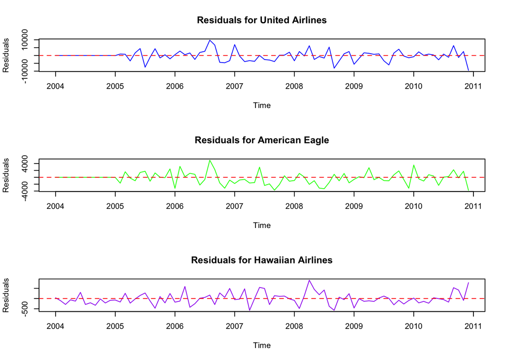

```r
united_residuals <- residuals(united_model)
american_residuals <- residuals(american_model)
hawaiian_residuals <- residuals(hawaiian_model)

residuals_df <- data.frame(
  Time = time(united_residuals),
  United = as.numeric(united_residuals),
  American = as.numeric(american_residuals),
  Hawaiian = as.numeric(hawaiian_residuals)
)

par(mfrow = c(3, 1))
plot(united_residuals, main = "Residuals for United Airlines", ylab = "Residuals", col = "blue")
abline(h = 0, col = "red", lty = 2)
plot(american_residuals, main = "Residuals for American Eagle", ylab = "Residuals", col = "green")
abline(h = 0, col = "red", lty = 2)
plot(hawaiian_residuals, main = "Residuals for Hawaiian Airlines", ylab = "Residuals", col = "purple")
abline(h = 0, col = "red", lty = 2)
```

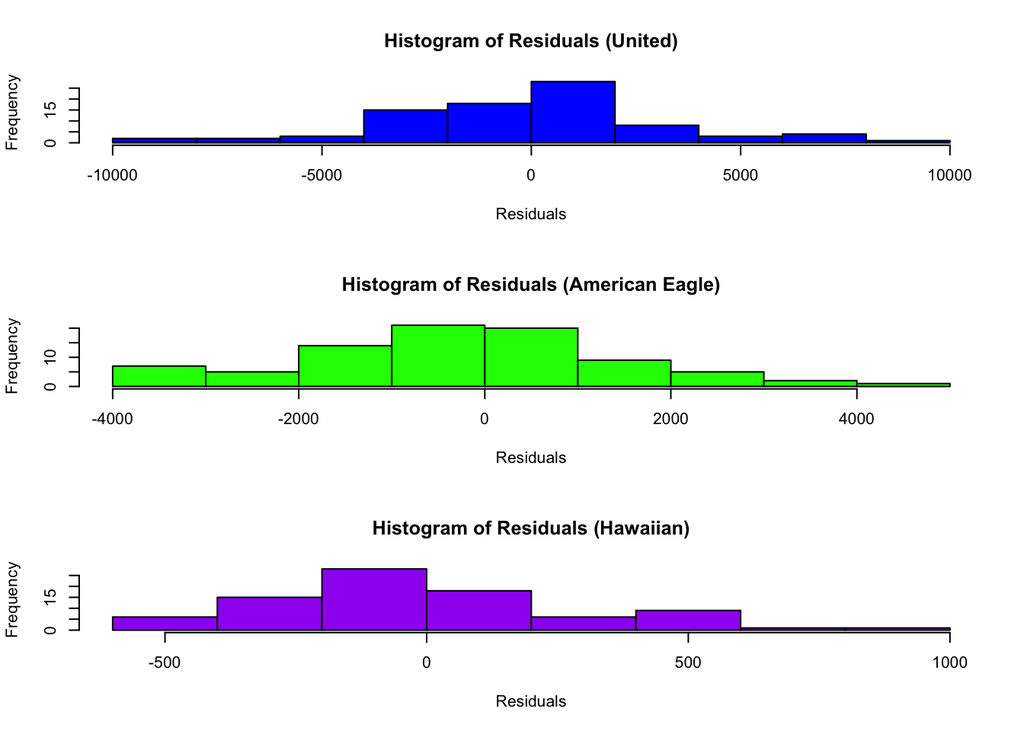

```r
par(mfrow = c(3, 1))
hist(united_residuals, main = "Histogram of Residuals (United)", col = "blue", xlab = "Residuals")
hist(american_residuals, main = "Histogram of Residuals (American Eagle)", col = "green", xlab = "Residuals")
hist(hawaiian_residuals, main = "Histogram of Residuals (Hawaiian)", col = "purple", xlab = "Residuals")
```

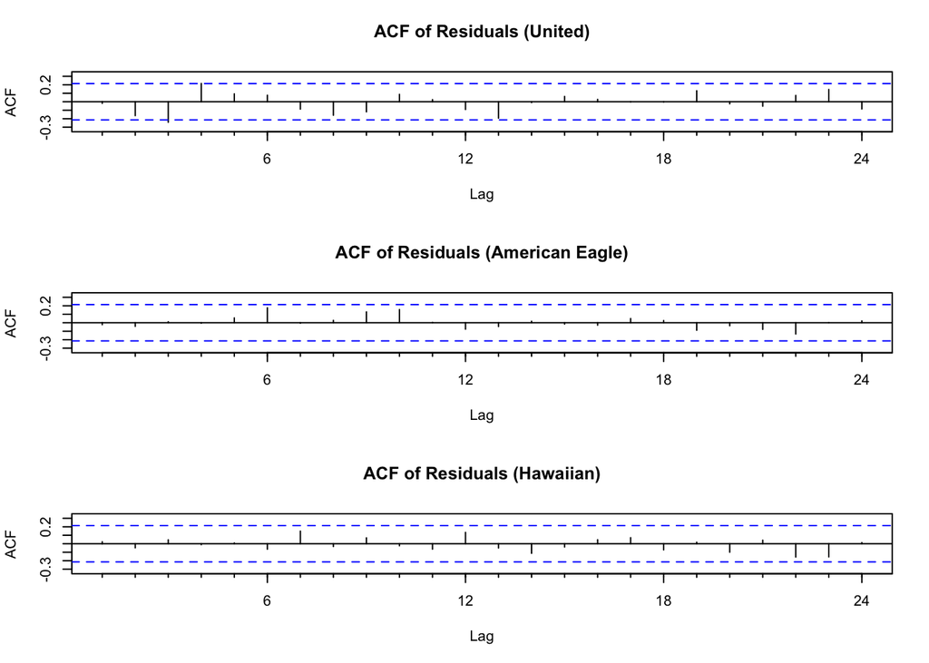

```r
par(mfrow = c(3, 1))
Acf(united_residuals, main = "ACF of Residuals (United)")
Acf(american_residuals, main = "ACF of Residuals (American Eagle)")
Acf(hawaiian_residuals, main = "ACF of Residuals (Hawaiian)")
```

```r
united_lb <- Box.test(united_residuals, lag = 20, type = "Ljung-Box")
american_lb <- Box.test(american_residuals, lag = 20, type = "Ljung-Box")
hawaiian_lb <- Box.test(hawaiian_residuals, lag = 20, type = "Ljung-Box")

print("Ljung-Box Test Results:")
```

```
## [1] "Ljung-Box Test Results:"
```

```r
print(united_lb)
```

```
##
##  Box-Ljung test
##
## data:  united_residuals
## X-squared = 25.524, df = 20, p-value = 0.1821
```

```r
print(american_lb)
```

```
##
##  Box-Ljung test
##
## data:  american_residuals
## X-squared = 9.6946, df = 20, p-value = 0.9734
```

```r
print(hawaiian_lb)
```

```
##
##  Box-Ljung test
##
## data:  hawaiian_residuals
## X-squared = 10.004, df = 20, p-value = 0.9681
```

```r
residual_stats <- data.frame(
  Airline = c("United", "American Eagle", "Hawaiian"),
  Variance = c(var(united_residuals), var(american_residuals), var(hawaiian_residuals)),
  Mean = c(mean(united_residuals), mean(american_residuals), mean(hawaiian_residuals)),
  SD = c(sd(united_residuals), sd(american_residuals), sd(hawaiian_residuals))
)
print(residual_stats)
```

```
##          Airline   Variance         Mean        SD
## 1         United 10885622.2 -197.2741562 3299.3366
## 2 American Eagle  2870515.0 -249.3458908 1694.2594
## 3       Hawaiian    85834.8   -0.6317617  292.9758
```

**United Airlines** - The distribution is centered around zero, which suggests normal distribution.

**American Eagle** - The histogram shows a reasonably symmetrical distribution around zero.

#### 3. Perform and Plot the forecast for the next five periods

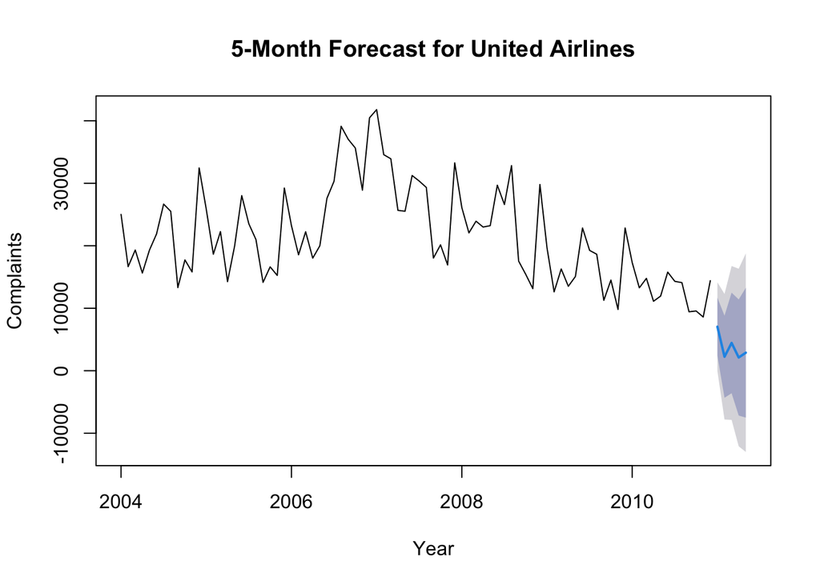

```r
united_forecast <- forecast(united_model, h = 5)
plot(united_forecast, main = "5-Month Forecast for United Airlines", xlab = "Year", ylab = "Complaints")
```

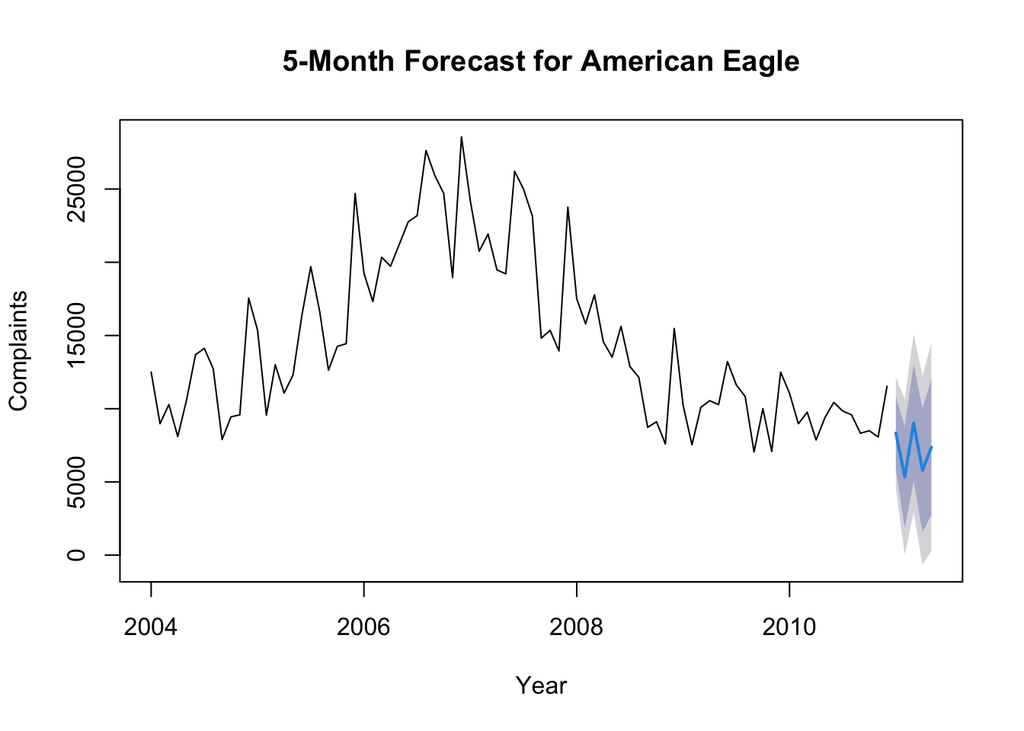

```r
american_forecast <- forecast(american_model, h = 5)
plot(american_forecast, main = "5-Month Forecast for American Eagle", xlab = "Year", ylab = "Complaints")
```

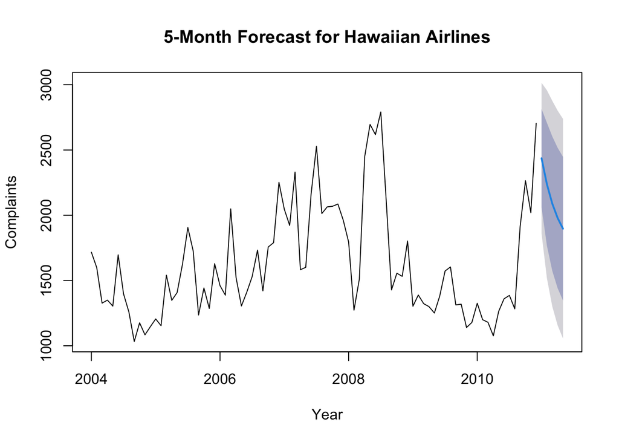

```r
hawaiian_forecast <- forecast(hawaiian_model, h = 5)
plot(hawaiian_forecast, main = "5-Month Forecast for Hawaiian Airlines", xlab = "Year", ylab = "Complaints")
```

```r
print("United Airlines Forecast:")
```

```
## [1] "United Airlines Forecast:"
```

```r
print(united_forecast)
```

```
##          Point Forecast     Lo 80     Hi 80        Lo 95    Hi 95
## Jan 2011       7047.557  2401.746 11693.367    -57.59695 14152.71
## Feb 2011       2242.951 -4327.217  8813.119  -7805.25338 12291.16
## Mar 2011       4447.619 -3599.160 12494.399  -7858.86794 16754.11
## Apr 2011       2118.132 -7173.488 11409.753 -12092.17512 16328.44
## May 2011       2887.827 -7500.520 13276.175 -12999.77939 18775.43
```

```r
print("American Eagle Forecast:")
```

```
## [1] "American Eagle Forecast:"
```

```r
print(american_forecast)
```

```
##          Point Forecast    Lo 80     Hi 80      Lo 95    Hi 95
## Jan 2011       8336.943 5850.434 10823.453 4534.15489 12139.73
## Feb 2011       5334.698 1858.261  8811.135   17.94689 10651.45
## Mar 2011       9012.756 5024.900 13000.612 2913.85646 15111.65
## Apr 2011       5798.297 1577.215 10019.380 -657.29127 12253.89
## May 2011       7365.286 2721.696 12008.876  263.52855 14467.04
```

```r
print("Hawaiian Airlines Forecast:")
```

```
## [1] "Hawaiian Airlines Forecast:"
```

```r
print(hawaiian_forecast)
```

```
##          Point Forecast    Lo 80    Hi 80    Lo 95    Hi 95
## Jan 2011       2436.894 2059.147 2814.640 1859.179 3014.608
## Feb 2011       2237.523 1766.781 2708.266 1517.585 2957.462
## Mar 2011       2089.266 1574.260 2604.273 1301.632 2876.901
## Apr 2011       1979.019 1441.098 2516.941 1156.339 2801.699
## May 2011       1897.037 1346.853 2447.220 1055.604 2738.470
```

**United Airlines**

- For January 2011, complaints are expected to be around 7,048
- The forecast is less reliable and shows high uncertainty.

**American Eagle**

- For the next 5 months, the predicted complaints are more stable, ranging from 5,335 to 9,013 on average.

#### 4. Show the accuracy of your ARIMA model

```r
united_accuracy <- accuracy(united_forecast)
print("United Airlines Model Accuracy:")
```

```
## [1] "United Airlines Model Accuracy:"
```

```r
print(united_accuracy)
```

```
##                     ME     RMSE      MAE        MPE     MAPE      MASE
## Training set -197.2742 3285.567 2328.996 -0.8866611 11.60956 0.3750866
##                     ACF1
## Training set -0.01895415
```

```r
american_accuracy <- accuracy(american_forecast)
print("American Eagle Model Accuracy:")
```

```
## [1] "American Eagle Model Accuracy:"
```

```r
print(american_accuracy)
```

```
##                     ME     RMSE      MAE       MPE     MAPE     MASE
## Training set -249.3459 1702.503 1255.412 -1.449956 8.770816 0.272565
##                     ACF1
## Training set -0.02248235
```

```r
hawaiian_accuracy <- accuracy(hawaiian_forecast)
print("Hawaiian Airlines Model Accuracy:")
```

```
## [1] "Hawaiian Airlines Model Accuracy:"
```

```r
print(hawaiian_accuracy)
```

```
##                      ME     RMSE      MAE       MPE     MAPE      MASE
## Training set -0.6317617 291.2273 221.2812 -2.930318 13.46231 0.5061873
##                    ACF1
## Training set 0.02367986
```

#### Conclusion

American Eagle has the lowest MAPE, indicating the most accurate model.

United Airlines has moderate MAPE but still better than Hawaiian Airlines.

Hawaiian Airlines higher MAPE could be due to the small scale of complaint values.